# Exercício: SARIMA no comércio varejista brasileiro

- Mostrar o código
- Esconder o código
- Ver o código fonte

PMC/IBGE · varejo ampliado · São Paulo — Financial Analytics, Insper PADS

Aluno

Curso

Luiz Felipe Possebon

Insper — PADS, Financial Analytics

Data

24/10/2026

## 1 Sobre o exercício

A base é a **PMC** (Pesquisa Mensal do Comércio) do IBGE: índice de volume de vendas no **comércio varejista ampliado** (inclui veículos e materiais de construção), por **Unidade da Federação**, mensal de jan/2004 em diante. Base 2022 = 100, **sem ajuste sazonal**.

**UF analisada: São Paulo.**

Passos pedidos no enunciado:

3. Análise descritiva (linha, ACF, PACF, diferenciação) e diagnóstico de tendência/sazonalidade.
4. Testes de raiz unitária (ADF, KPSS) e estimativa de `ndiffs`.
5. Ajuste de SARIMA via `AutoARIMA(season_length=12)`.
6. Diagnóstico dos resíduos.
7. Previsão de 24 meses à frente, com intervalos de 80% e 95%.
8. Discussão dos resultados.

### 1.1 Roteiro metodológico

Este relatório segue, **na ordem**, o procedimento **Box-Jenkins**, conforme apresentado em aula:

| Etapa Box-Jenkins | Seção deste relatório | Conceitos e ferramentas |
| --- | --- | --- |
| **1. Identificação**: componentes, ACF/PACF, $d$ e $D$ | 5 · Análise descritiva 6 · Testes de raiz unitária | componentes e decomposição STL, ACF/PACF, testes ADF + KPSS, diferenciação regular e sazonal |
| **2. Estimação**: MLE + AICc | 7 · Modelagem | SARIMA estimado por máxima verossimilhança, seleção via `AutoARIMA` (Hyndman-Khandakar) |
| **3. Diagnóstico**: resíduos = ruído branco? | 8 · Diagnóstico dos resíduos | resíduos no tempo, ACF residual, normalidade, teste de Ljung-Box |
| **4. Previsão** com intervalos | 9 · Previsão | previsão de 24 meses com intervalos de 80% e 95% |

A análise descritiva segue a ordem recomendada em aula para séries sazonais (é também a ordem interna do `AutoARIMA`):

1. gráfico da série completa;
2. decomposição STL;
3. boxplot por mês;
4. ACF da série original;
5. ACF/PACF de $\Delta_{12} Y_t$ e teste de raiz unitária.

Primeiro se remove a sazonalidade e só depois se decide se ainda falta a diferença regular ($D \to d$).

## 2 Setup

Imports do template, mais as bibliotecas para STL, diagnóstico de resíduos e `ndiffs`/`nsdiffs`, e o estilo dos gráficos.

**Código**

```python
import warnings
warnings.filterwarnings('ignore')

import numpy as np
import pandas as pd
import matplotlib.pyplot as plt
from scipy import stats

from statsmodels.tsa.stattools import adfuller, kpss, acf
from statsmodels.tsa.seasonal import STL
from statsmodels.graphics.tsaplots import plot_acf, plot_pacf
from statsmodels.graphics.gofplots import qqplot
from statsmodels.stats.diagnostic import acorr_ljungbox

from statsforecast import StatsForecast
from statsforecast.models import AutoARIMA, ARIMA
from statsforecast.arima import ndiffs, nsdiffs, seas_heuristic

# Estilo dos gráficos
plt.rcParams.update({
    'figure.figsize': (12, 5),
    'axes.spines.top': False,
    'axes.spines.right': False,
    'axes.grid': True,
    'grid.alpha': 0.3,
    'font.size': 11,
})

INSPER_RED = '#E50505'
INSPER_TURQUESA = '#3ACC9F'
INSPER_AMARELO = '#FFCC00'
INSPER_GRAY = '#5B5B5B'
INSPER_ROXO = '#730D9F'

S = 12                                                     # período sazonal (mensal → anual)
COVID = (pd.Timestamp('2020-03-01'), pd.Timestamp('2020-08-01'))
RECESSAO = (pd.Timestamp('2014-04-01'), pd.Timestamp('2016-12-01'))

MESES = ['jan', 'fev', 'mar', 'abr', 'mai', 'jun', 'jul', 'ago', 'set', 'out', 'nov', 'dez']


def mes_ano(ts):
    """Timestamp → 'jan/2004' (independe do locale do sistema)."""
    return f"{MESES[ts.month - 1]}/{ts.year}"
```

### 2.1 Funções auxiliares

Os gráficos de ACF/PACF marcam os lags sazonais (12, 24, 36), e o teste de estacionariedade devolve uma **tabela**, para comparar várias transformações lado a lado. A conclusão conjunta segue a lógica de triangulação ADF × KPSS.

**Código**

```python
def marcar_sazonais(ax, s=S, max_lag=36):
    """Linhas verticais nos lags sazonais s, 2s, 3s..."""
    for lag in range(s, max_lag + 1, s):
        ax.axvline(lag, color=INSPER_AMARELO, lw=6, alpha=0.25, zorder=0)


def plotar_diagnostico(serie, titulo, lags=36):
    """Série no topo; ACF e PACF lado a lado (lags sazonais destacados)."""
    serie = serie.dropna()
    fig = plt.figure(figsize=(13, 7))
    gs = fig.add_gridspec(2, 2, height_ratios=[1, 1])
    ax0 = fig.add_subplot(gs[0, :])
    ax0.plot(serie.index, serie.values, color=INSPER_RED, lw=1)
    ax0.axhline(serie.mean(), color=INSPER_GRAY, ls='--', alpha=0.6)
    ax0.axvspan(*COVID, color=INSPER_AMARELO, alpha=0.25, label='Covid (mar–ago/2020)')
    ax0.set_title(titulo, fontweight='bold')
    ax0.legend(loc='upper left', fontsize=9)

    ax1 = fig.add_subplot(gs[1, 0])
    plot_acf(serie, ax=ax1, lags=lags, zero=False, color=INSPER_GRAY,
             vlines_kwargs={'colors': INSPER_GRAY})
    marcar_sazonais(ax1, max_lag=lags)
    ax1.set_title('ACF')

    ax2 = fig.add_subplot(gs[1, 1])
    plot_pacf(serie, ax=ax2, lags=lags, zero=False, method='ywm', color=INSPER_GRAY,
              vlines_kwargs={'colors': INSPER_GRAY})
    marcar_sazonais(ax2, max_lag=lags)
    ax2.set_title('PACF')
    plt.tight_layout()
    plt.show()


def resumo_acf(serie, lags=(1, 2, 3, 12, 13, 24, 36)):
    """ACF e PACF em lags-chave + lista de lags significativos (banda ±1,96/√n)."""
    from statsmodels.tsa.stattools import pacf
    s = serie.dropna()
    ac, pa = acf(s, nlags=36), pacf(s, nlags=36, method='ywm')
    banda = 1.96 / np.sqrt(len(s))
    tab = pd.DataFrame({'ACF': ac[list(lags)], 'PACF': pa[list(lags)]},
                       index=pd.Index(lags, name='lag')).T.round(2)
    print(f"Banda de significância: ±{banda:.3f}  (n = {len(s)})")
    print("Lags significativos na ACF: ", [l for l in range(1, 37) if abs(ac[l]) > banda])
    print("Lags significativos na PACF:", [l for l in range(1, 37) if abs(pa[l]) > banda])
    return tab


def testar_estacionariedade(series, alpha=0.05):
    """ADF (H0: raiz unitária) e KPSS (H0: estacionária) para um dicionário de séries."""
    linhas = {}
    for nome, serie in series.items():
        s = serie.dropna()
        adf_stat, adf_p, adf_lags, *_ = adfuller(s, autolag='AIC')
        with warnings.catch_warnings():                      # p-valor fora da tabela → aviso; tratamos abaixo
            warnings.simplefilter('ignore')
            kpss_stat, kpss_p, *_ = kpss(s, regression='c', nlags='auto')
        # o KPSS tabula p-valores só entre 0,01 e 0,10 → fora disso, reportamos o limite
        kpss_txt = ('< 0.01' if kpss_p <= 0.01 else '> 0.10' if kpss_p >= 0.10
                    else f'{kpss_p:.3f}')
        adf_rejeita, kpss_rejeita = adf_p < alpha, kpss_p < alpha
        if adf_rejeita and not kpss_rejeita:
            conclusao = '✅ estacionária'
        elif not adf_rejeita and kpss_rejeita:
            conclusao = '⚠️ raiz unitária → diferenciar'
        elif adf_rejeita and kpss_rejeita:
            conclusao = '❓ inconclusivo (ambos rejeitam)'
        else:
            conclusao = '❓ inconclusivo (nenhum rejeita)'
        linhas[nome] = {'n': len(s), 'ADF estat.': round(adf_stat, 3),
                        'ADF p-valor': round(adf_p, 4), 'ADF lags': adf_lags,
                        'KPSS estat.': round(kpss_stat, 3), 'KPSS p-valor': kpss_txt,
                        'Conclusão conjunta': conclusao}
    return pd.DataFrame(linhas).T
```

## 3 Carregando a base PMC

A base já foi pré-processada para conter apenas as colunas relevantes, e já no formato “long” (uma linha por data + UF). O nome da coluna de data é “data”, e a coluna de interesse (índice de volume) é “volume_idx”. A coluna “uf” indica a Unidade da Federação.

**Código**

```python
pmc = pd.read_csv("https://github.com/padsInsper/202634-fa/releases/download/data/pmc_volume_uf.csv")
pmc['data'] = pd.to_datetime(pmc['data'])

print(f"Dimensões: {pmc.shape[0]} linhas × {pmc.shape[1]} colunas")
print(f"Período:   {mes_ano(pmc['data'].min())} → {mes_ano(pmc['data'].max())}")
print(f"UFs:       {pmc['uf'].nunique()}")
print(f"Valores ausentes por coluna: {pmc.isna().sum().to_dict()}")
pmc.head()
```

```
Dimensões: 7182 linhas × 3 colunas
Período:   jan/2004 → fev/2026
UFs:       27
Valores ausentes por coluna: {'uf': 0, 'data': 0, 'volume_idx': 0}
```

|  | uf | data | volume_idx |
| --- | --- | --- | --- |
| 0 | Acre | 2004-01-01 | 18.16706 |
| 1 | Acre | 2004-02-01 | 17.24721 |
| 2 | Acre | 2004-03-01 | 20.77331 |
| 3 | Acre | 2004-04-01 | 19.24022 |
| 4 | Acre | 2004-05-01 | 21.46320 |

## 4 Escolha sua UF

O `statsforecast` usa o formato Nixtla: `unique_id`, `ds`, `y`. Para as análises com `statsmodels`, também guardamos a série como `pd.Series` indexada por data, com frequência mensal (`MS`).

**Código**

```python
MINHA_UF = "São Paulo"


df_sf = (
    pmc.query("uf == @MINHA_UF")
    .rename(columns={"uf": "unique_id", "data": "ds", "volume_idx": "y"})
    [["unique_id", "ds", "y"]]
    .reset_index(drop=True)
)

# Série indexada por data, para statsmodels (STL, ACF/PACF, ADF/KPSS)
y = df_sf.set_index('ds')['y'].asfreq('MS')
y.name = 'volume_idx'

print(f"{MINHA_UF}: {len(y)} meses ({mes_ano(y.index[0])} → {mes_ano(y.index[-1])}), "
      f"{y.isna().sum()} valores ausentes")
df_sf.head()
```

```
São Paulo: 266 meses (jan/2004 → fev/2026), 0 valores ausentes
```

|  | unique_id | ds | y |
| --- | --- | --- | --- |
| 0 | São Paulo | 2004-01-01 | 52.53519 |
| 1 | São Paulo | 2004-02-01 | 50.98433 |
| 2 | São Paulo | 2004-03-01 | 57.18775 |
| 3 | São Paulo | 2004-04-01 | 54.76454 |
| 4 | São Paulo | 2004-05-01 | 57.09082 |

**Código**

```python
# Estatísticas descritivas e média anual (2026 tem só jan–fev)
display(y.describe().round(2).to_frame().T)
media_anual = y.groupby(y.index.year).mean().round(1)
media_anual.to_frame('média anual').T
```

|  | count | mean | std | min | 25% | 50% | 75% | max |
| --- | --- | --- | --- | --- | --- | --- | --- | --- |
| volume_idx | 266.0 | 90.94 | 17.66 | 48.27 | 81.17 | 95.46 | 102.8 | 132.5 |

| ds | 2004 | 2005 | 2006 | 2007 | 2008 | 2009 | 2010 | 2011 | 2012 | 2013 | ... | 2017 | 2018 | 2019 | 2020 | 2021 | 2022 | 2023 | 2024 | 2025 | 2026 |
| --- | --- | --- | --- | --- | --- | --- | --- | --- | --- | --- | --- | --- | --- | --- | --- | --- | --- | --- | --- | --- | --- |
| média anual | 57.8 | 58.1 | 60.1 | 68.8 | 76.6 | 82.6 | 91.6 | 96.9 | 106.3 | 109.5 | ... | 92.2 | 97.9 | 103.0 | 99.7 | 101.4 | 100.0 | 102.9 | 104.3 | 101.3 | 92.8 |

1 rows × 23 columns

## 5 Análise descritiva

Esta é a **Etapa 1 do Box-Jenkins (Identificação)**. Antes de qualquer modelo, olhamos a série por cinco ângulos, na ordem descrita acima.

### 5.1 Gráfico de linha

Junto com a série, plotamos a média móvel centrada de 12 meses. Ela elimina a sazonalidade anual e mostra a tendência/ciclo.

**Código**

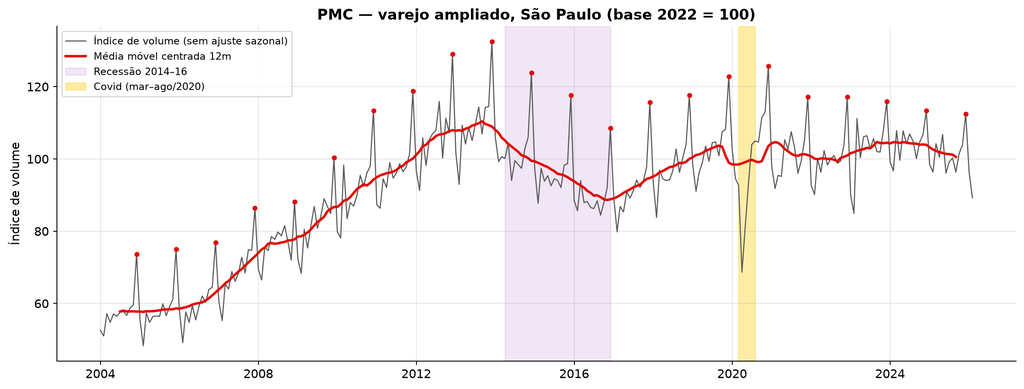

```python
mm12 = y.rolling(12, center=True).mean()

fig, ax = plt.subplots(figsize=(13, 5))
ax.plot(y.index, y.values, color=INSPER_GRAY, lw=1, label='Índice de volume (sem ajuste sazonal)')
ax.plot(mm12.index, mm12.values, color=INSPER_RED, lw=2.2, label='Média móvel centrada 12m')
ax.axvspan(*RECESSAO, color=INSPER_ROXO, alpha=0.10, label='Recessão 2014–16')
ax.axvspan(*COVID, color=INSPER_AMARELO, alpha=0.35, label='Covid (mar–ago/2020)')
for dez in y[y.index.month == 12].index:          # marca os dezembros
    ax.plot(dez, y[dez], 'o', color=INSPER_RED, ms=3.5)
ax.set_title(f'PMC — varejo ampliado, {MINHA_UF} (base 2022 = 100)', fontweight='bold')
ax.set_ylabel('Índice de volume')
ax.legend(loc='upper left', fontsize=9)
plt.tight_layout(); plt.show()
```

**Observe e anote:**

1. **Tendência?** Sim, e não é linear: parece uma **tendência estocástica** (o nível “vagueia”).
   - O índice sobe de ≈ 58 (média de 2004) até ≈ 110 (2013).
   - Cai cerca de 18% na recessão 2014–16 (≈ 90 em 2016).
   - Recupera até ≈ 103 em 2019 e, desde 2021, oscila ao redor de 100–104.
   - Uma tendência determinística, $\alpha + \beta t$, não descreveria essa trajetória. O padrão é típico de raiz unitária.
2. **Sazonalidade?** Sim, **anual ($s = 12$)** e muito nítida. Os pontos vermelhos (dezembros) são sempre o pico do ano (Natal e 13º salário). Fevereiro e janeiro aparecem como vales.
3. **Outliers ou quebras?**
   - A quebra mais visível é o **Covid**: o índice cai de 92,7 (mar/2020) para 68,7 (abr/2020) e volta a ≈ 104 já em jul/2020.
   - A recessão de 2014–16 é uma mudança de nível mais lenta, não um outlier.
4. **Variância constante?** Não exatamente. A amplitude do zigue-zague sazonal **cresce** com o nível até 2013–14 e depois **encolhe**, mesmo com o nível estável. Isso sugere uma sazonalidade que **muda ao longo do tempo**, o que a STL e o boxplot vão confirmar.

### 5.2 Decomposição STL

Usamos a STL robusta (`robust=True`, para o choque do Covid não distorcer os componentes). A partir dela calculamos as **forças de tendência e de sazonalidade** (Wang, Smith & Hyndman, 2006), as mesmas que o `AutoARIMA` usa para decidir $D$:

$$F_T = \max\left\{0,\ 1 - \frac{\mathrm{Var}(R_t)}{\mathrm{Var}(T_t + R_t)}\right\}, \qquad
F_S = \max\left\{0,\ 1 - \frac{\mathrm{Var}(R_t)}{\mathrm{Var}(S_t + R_t)}\right\}$$

**Código**

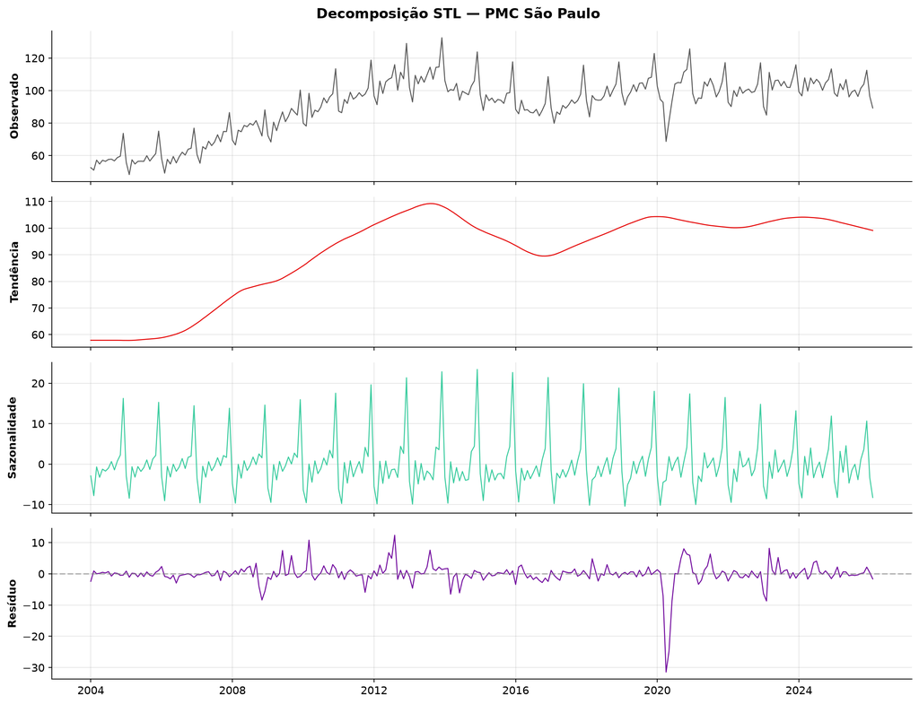

```
Força da tendência     F_T = 0.95
Força da sazonalidade  F_S = 0.77   (limiar do AutoARIMA para aplicar Δ12: 0,64)
```

```python
stl = STL(y, period=S, robust=True).fit()

fig, axes = plt.subplots(4, 1, figsize=(13, 10), sharex=True)
componentes = {'Observado': y, 'Tendência': stl.trend,
               'Sazonalidade': stl.seasonal, 'Resíduo': stl.resid}
cores = [INSPER_GRAY, INSPER_RED, INSPER_TURQUESA, INSPER_ROXO]
for ax, (nome, comp), cor in zip(axes, componentes.items(), cores):
    ax.plot(comp.index, comp.values, color=cor, lw=1)
    ax.set_ylabel(nome, fontweight='bold')
axes[3].axhline(0, color='gray', ls='--', alpha=0.5)
plt.suptitle(f'Decomposição STL — PMC {MINHA_UF}', fontsize=14, fontweight='bold')
plt.tight_layout(); plt.show()

F_T = max(0, 1 - np.var(stl.resid) / np.var(stl.trend + stl.resid))
F_S = max(0, 1 - np.var(stl.resid) / np.var(stl.seasonal + stl.resid))
print(f"Força da tendência     F_T = {F_T:.2f}")
print(f"Força da sazonalidade  F_S = {F_S:.2f}   (limiar do AutoARIMA para aplicar Δ12: 0,64)")
```

**Código**

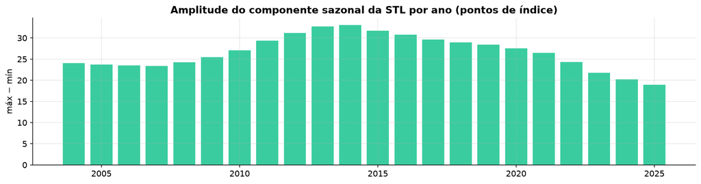

| ds | 2004 | 2005 | 2006 | 2007 | 2008 | 2009 | 2010 | 2011 | 2012 | 2013 | ... | 2016 | 2017 | 2018 | 2019 | 2020 | 2021 | 2022 | 2023 | 2024 | 2025 |
| --- | --- | --- | --- | --- | --- | --- | --- | --- | --- | --- | --- | --- | --- | --- | --- | --- | --- | --- | --- | --- | --- |
| amplitude | 24.1 | 23.7 | 23.5 | 23.4 | 24.3 | 25.4 | 27.1 | 29.4 | 31.2 | 32.7 | ... | 30.8 | 29.6 | 29.0 | 28.4 | 27.6 | 26.5 | 24.3 | 21.8 | 20.2 | 18.9 |

1 rows × 22 columns

```python
# A sazonalidade é estável? Amplitude anual do componente sazonal (máx − mín), anos completos
amplitude = stl.seasonal.groupby(stl.seasonal.index.year).agg(lambda s: s.max() - s.min())
amplitude = amplitude[amplitude.index < 2026]

fig, ax = plt.subplots(figsize=(13, 3.5))
ax.bar(amplitude.index, amplitude.values, color=INSPER_TURQUESA)
ax.set_title('Amplitude do componente sazonal da STL por ano (pontos de índice)', fontweight='bold')
ax.set_ylabel('máx − mín')
plt.tight_layout(); plt.show()

amplitude.round(1).to_frame('amplitude').T
```

**Leitura.**

- **$F_T \approx 0{,}95$** e **$F_S \approx 0{,}77$**: os dois componentes são fortes. Pela heurística do `AutoARIMA`, $F_S > 0{,}64$ já indica que haverá **diferença sazonal ($D = 1$)**.
- A tendência STL reproduz o ciclo da economia: expansão até 2013, recessão 2014–16, recuperação, Covid e estabilidade recente.
- No componente sazonal, dezembro fica cerca de 17 pontos acima da tendência e fevereiro cerca de 9 abaixo.
- A **amplitude sazonal não é constante**. Ela vai de ≈ 24 pontos (2004) a ≈ 33 (2014) e cai para ≈ 19 (2025).
  - Até 2014, a amplitude acompanha o nível, um comportamento de tipo multiplicativo.
  - Depois de 2014, encolhe com o nível estável, ou seja, a sazonalidade **evolui**.
- Pela distinção entre sazonalidade determinística e estocástica, isso aponta para uma **sazonalidade estocástica**. Ela se trata com $\Delta_{12}$ e termos $(P, Q)$, e não com dummies fixas de mês.
- O resíduo da STL é pequeno, exceto no **Covid** (abr/2020), exatamente o que a versão robusta isola.

### 5.3 Boxplot por mês e gráfico sazonal

O boxplot mostra o **perfil médio** de cada mês. O gráfico sazonal (uma linha por ano) e a razão “mês ÷ média do ano” mostram se esse perfil **muda ao longo do tempo**.

**Código**

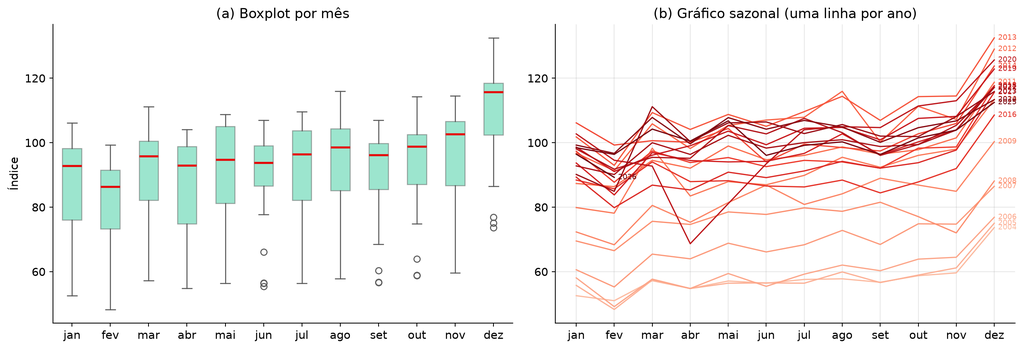

```python
meses = MESES
dados = pd.DataFrame({'y': y, 'ano': y.index.year, 'mes': y.index.month})

fig, axes = plt.subplots(1, 2, figsize=(14, 5))

# (a) Boxplot por mês
dados.boxplot(column='y', by='mes', ax=axes[0], grid=False, patch_artist=True,
              boxprops=dict(facecolor=INSPER_TURQUESA, alpha=0.5, color=INSPER_GRAY),
              medianprops=dict(color=INSPER_RED, lw=2),
              whiskerprops=dict(color=INSPER_GRAY), capprops=dict(color=INSPER_GRAY),
              flierprops=dict(markeredgecolor=INSPER_GRAY))
axes[0].set_xticklabels(meses)
axes[0].set_title('(a) Boxplot por mês'); axes[0].set_xlabel(''); axes[0].set_ylabel('Índice')

# (b) Gráfico sazonal: uma linha por ano, cor do mais antigo (claro) ao mais recente (escuro)
anos = sorted(dados['ano'].unique())
cmap = plt.cm.Reds(np.linspace(0.25, 1, len(anos)))
for cor, ano in zip(cmap, anos):
    d = dados[dados['ano'] == ano]
    axes[1].plot(d['mes'], d['y'], color=cor, lw=1.2)
    axes[1].text(d['mes'].iloc[-1] + 0.1, d['y'].iloc[-1], str(ano), fontsize=7, color=cor, va='center')
axes[1].set_xticks(range(1, 13)); axes[1].set_xticklabels(meses)
axes[1].set_title('(b) Gráfico sazonal (uma linha por ano)')
plt.suptitle(''); plt.tight_layout(); plt.show()
```

**Código**

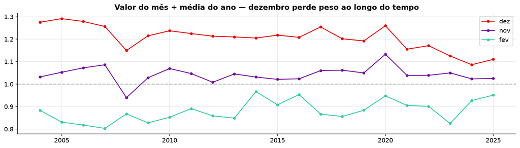

| ano | 2004 | 2007 | 2010 | 2013 | 2016 | 2019 | 2022 | 2025 |
| --- | --- | --- | --- | --- | --- | --- | --- | --- |
| jan | 0.910 | 0.880 | 0.871 | 0.929 | 0.984 | 0.957 | 0.928 | 0.971 |
| fev | 0.883 | 0.803 | 0.852 | 0.849 | 0.954 | 0.884 | 0.901 | 0.951 |
| nov | 1.032 | 1.086 | 1.069 | 1.045 | 1.024 | 1.050 | 1.039 | 1.025 |
| dez | 1.276 | 1.256 | 1.237 | 1.210 | 1.208 | 1.192 | 1.171 | 1.110 |

```python
# Peso de cada mês no próprio ano: valor do mês ÷ média do ano (anos completos)
completos = dados[dados['ano'] < 2026]
razao = completos['y'] / completos.groupby('ano')['y'].transform('mean')
razao = razao.groupby([completos['ano'], completos['mes']]).first().unstack()
razao.columns = meses

fig, ax = plt.subplots(figsize=(13, 3.8))
for mes, cor in [('dez', INSPER_RED), ('nov', INSPER_ROXO), ('fev', INSPER_TURQUESA)]:
    ax.plot(razao.index, razao[mes], 'o-', color=cor, lw=1.5, ms=4, label=mes)
ax.axhline(1, color='gray', ls='--', alpha=0.6)
ax.set_title('Valor do mês ÷ média do ano — dezembro perde peso ao longo do tempo', fontweight='bold')
ax.legend(); plt.tight_layout(); plt.show()

razao[['jan', 'fev', 'nov', 'dez']].iloc[::3].round(3).T
```

**Leitura.**

- **Perfil sazonal:**
  - **Dezembro** é o grande pico. Em média, vale ≈ 20% acima da média do ano.
  - **Fevereiro** (mês curto e com Carnaval) e **janeiro** são os vales.
  - **Abril, junho e setembro** ficam um pouco abaixo da média.
  - **Novembro** vem logo acima, antecipando parte das compras de fim de ano.
- **A caixa de cada mês é larga** porque a série tem **tendência**: o mesmo mês vale ≈ 55 em 2004 e ≈ 100 em 2024. É mais um sinal de que o nível precisa ser diferenciado antes de modelar.
- **O perfil sazonal muda.**
  - No gráfico sazonal, as linhas recentes (escuras) têm um pico de dezembro relativamente menor.
  - Na razão mês ÷ média anual, o peso de dezembro cai de ≈ 1,28 (2004) para ≈ 1,11 (2025).
  - Uma hipótese é a redistribuição das compras de fim de ano, com a Black Friday em novembro e o comércio eletrônico, mas os dados não permitem testá-la.
  - Seja qual for a causa, uma sazonalidade que se desloca é **estocástica**, coerente com $D = 1$.

### 5.4 ACF e PACF da série original

**Código**

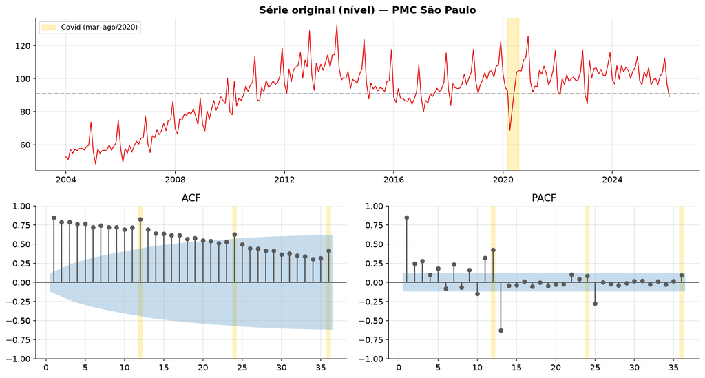

```
Banda de significância: ±0.120  (n = 266)
Lags significativos na ACF:  [1, 2, 3, 4, 5, 6, 7, 8, 9, 10, 11, 12, 13, 14, 15, 16, 17, 18, 19, 20, 21, 22, 23, 24, 25, 26, 27, 28, 29, 30, 31, 32, 33, 34, 35, 36]
Lags significativos na PACF: [1, 2, 3, 5, 7, 9, 10, 11, 12, 13, 25]
```

| lag | 1 | 2 | 3 | 12 | 13 | 24 | 36 |
| --- | --- | --- | --- | --- | --- | --- | --- |
| ACF | 0.85 | 0.79 | 0.79 | 0.83 | 0.69 | 0.63 | 0.41 |
| PACF | 0.85 | 0.24 | 0.28 | 0.43 | -0.63 | 0.08 | 0.09 |

```python
plotar_diagnostico(y, f'Série original (nível) — PMC {MINHA_UF}')
resumo_acf(y)
```

**Leitura.**

- **ACF:** $\rho_1 \approx 0{,}85$, com **decaimento muito lento**. Todos os 36 lags ficam fora da banda.
  - Pela regra de identificação (“ACF não decai → não estacionário”), essa é a assinatura da **tendência / raiz unitária**.
- **Lags sazonais:** sobre esse decaimento aparecem **picos em 12 (≈ 0,83), 24 (≈ 0,63) e 36 (≈ 0,41)**, que também decaem devagar.
  - Picos persistentes em $s, 2s, 3s$ são a assinatura de **sazonalidade estocástica**, que pede $\Delta_{12}$.
- **PACF:** pico grande no lag 1 (≈ 0,85) e picos nos lags **12 (≈ 0,43) e 13 (≈ −0,63)**.
  - O par 12/13 é o padrão de uma série que depende fortemente do mesmo mês do ano anterior.
- **Bate com o gráfico de linha?** Sim: há tendência e sazonalidade anual. **Nenhum modelo ARMA deve ser identificado no nível.** Primeiro é preciso diferenciar.

### 5.5 Diferenciação

Seguindo a ordem $D \to d$, aplicamos primeiro a **diferença sazonal** $\Delta_{12} Y_t = Y_t - Y_{t-12}$ (variação contra o mesmo mês do ano anterior). Só depois vemos se ainda falta a diferença regular.

#### 5.5.1 Diferença sazonal: $\Delta_{12} Y_t$

**Código**

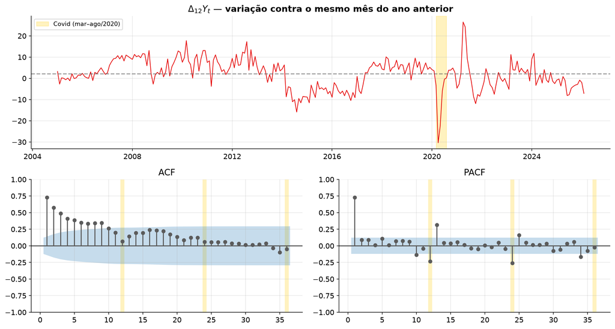

```
Banda de significância: ±0.123  (n = 254)
Lags significativos na ACF:  [1, 2, 3, 4, 5, 6, 7, 8, 9, 10, 11, 13, 14, 15, 16, 17, 18, 19, 20]
Lags significativos na PACF: [1, 10, 12, 13, 24, 25, 34]
```

| lag | 1 | 2 | 3 | 12 | 13 | 24 | 36 |
| --- | --- | --- | --- | --- | --- | --- | --- |
| ACF | 0.73 | 0.57 | 0.49 | 0.06 | 0.14 | 0.06 | -0.05 |
| PACF | 0.73 | 0.09 | 0.09 | -0.23 | 0.32 | -0.26 | -0.03 |

```python
y_d12 = y.diff(12)
plotar_diagnostico(y_d12, r'$\Delta_{12} Y_t$ — variação contra o mesmo mês do ano anterior')
resumo_acf(y_d12)
```

**Leitura.**

- A diferença sazonal **removeu os picos sazonais**: a ACF no lag 12 caiu de 0,83 para ≈ 0,06.
- Mas a ACF ainda **decai lentamente** a partir de ≈ 0,73 e continua significativa até o lag ≈ 20.
- No gráfico, $\Delta_{12} Y_t$ passa anos acima de zero (2007–13) e anos abaixo (2014–16). Isso é o ciclo econômico, que a diferença sazonal não remove.
- Portanto **ainda falta a diferença regular** ($d = 1$). O teste KPSS na próxima seção vai confirmar.

#### 5.5.2 Contraprova: só a diferença regular, $\Delta Y_t$

Para mostrar por que a ordem importa, vale ver o que acontece se aplicarmos **apenas** a diferença regular.

**Código**

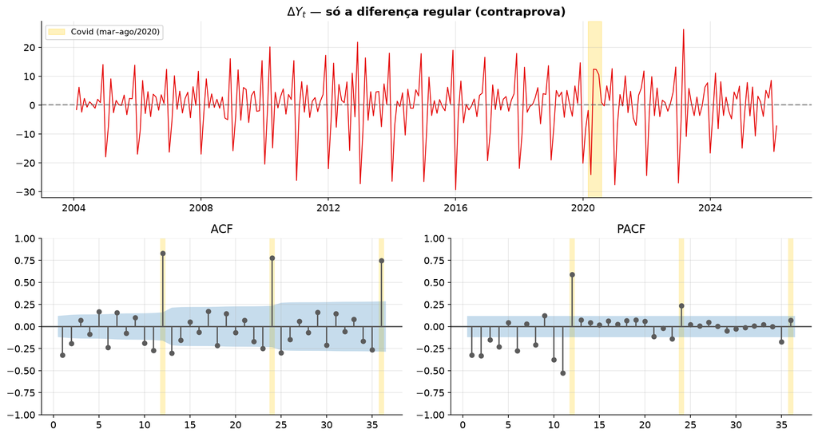

```
Banda de significância: ±0.120  (n = 265)
Lags significativos na ACF:  [1, 2, 5, 6, 7, 10, 11, 12, 13, 14, 17, 18, 19, 22, 23, 24, 25, 26, 29, 30, 31, 34, 35, 36]
Lags significativos na PACF: [1, 2, 3, 4, 6, 8, 9, 10, 11, 12, 23, 24, 35]
```

| lag | 1 | 2 | 3 | 12 | 13 | 24 | 36 |
| --- | --- | --- | --- | --- | --- | --- | --- |
| ACF | -0.32 | -0.19 | 0.07 | 0.83 | -0.30 | 0.78 | 0.75 |
| PACF | -0.32 | -0.33 | -0.15 | 0.59 | 0.07 | 0.24 | 0.07 |

```python
y_d1 = y.diff()
plotar_diagnostico(y_d1, r'$\Delta Y_t$ — só a diferença regular (contraprova)')
resumo_acf(y_d1)
```

**Leitura.**

- A tendência some: a série oscila em torno de zero.
- Mas a ACF tem **picos enormes e persistentes em 12 (≈ 0,83), 24 (≈ 0,78) e 36 (≈ 0,75)**, que praticamente não decaem. **A sazonalidade estocástica continua lá.**
- Como veremos, o ADF declara $\Delta Y_t$ “estacionária”. Mas **o ADF não vê sazonalidade**, então $D$ se decide olhando a ACF nos lags $s, 2s, 3s$.

#### 5.5.3 Diferença dupla: $\Delta \Delta_{12} Y_t$

**Código**

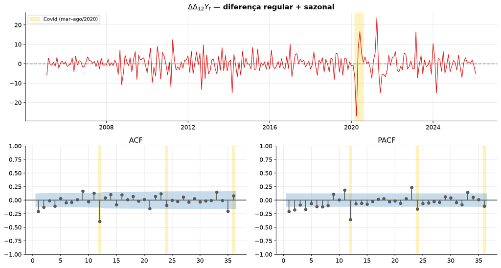

```
Banda de significância: ±0.123  (n = 253)
Lags significativos na ACF:  [1, 2, 9, 11, 12, 21, 33, 35]
Lags significativos na PACF: [1, 2, 4, 11, 12, 23, 24, 33]
```

| lag | 1 | 2 | 3 | 12 | 13 | 24 | 36 |
| --- | --- | --- | --- | --- | --- | --- | --- |
| ACF | -0.21 | -0.13 | -0.01 | -0.39 | 0.04 | -0.10 | 0.08 |
| PACF | -0.21 | -0.18 | -0.09 | -0.36 | -0.07 | -0.16 | -0.11 |

```python
y_dd = y.diff().diff(12)
plotar_diagnostico(y_dd, r'$\Delta\Delta_{12} Y_t$ — diferença regular + sazonal')
resumo_acf(y_dd)
```

**Leitura.** A série duplamente diferenciada oscila em torno de zero, sem tendência nem sazonalidade visível. O que sobra é o choque do Covid (abr–jun/2020) e o pico de mar/2023. A identificação dos termos ARMA segue a regra prática do Box-Jenkins estendido:

- **Lags pequenos → $p, q$:**
  - A ACF é significativa nos lags 1 (≈ −0,21) e 2 (≈ −0,13) e depois corta.
  - A PACF também tem lags 1 e 2 negativos e significativos.
  - Os candidatos são um **MA(1)/MA(2)** ou um **AR(2)** de baixa ordem. A tabela ACF/PACF raramente é limpa, e o AICc desempata.
- **Lags sazonais → $P, Q$:**
  - A ACF tem pico **negativo no lag 12 (≈ −0,39)** e nada no 24.
  - A PACF decai nos lags sazonais: 12 (≈ −0,36), depois 24 (≈ −0,16).
  - Pelo guia sazonal, pico na ACF em $s$ com PACF decaindo indica **SMA(1)**.
- **Sobrediferenciação?** O lag 1 negativo é moderado (−0,21), longe do ≈ −0,5 que indicaria diferença em excesso. Ou seja, $d = 1$ e $D = 1$ não parecem exagerados.
- **Lags isolados** (9, 11, 21, 33…) são esperados: com 36 lags a 5%, ≈ 2 falsos positivos acontecem por acaso. O Covid também infla algumas autocorrelações.

**Candidato pela leitura manual: SARIMA$(0,1,1)(0,1,1)_{12}$ (o *airline model*)**, ou uma variante com mais um termo não-sazonal. Na Seção 7, conferimos se o `AutoARIMA` concorda.

## 6 Testes de raiz unitária (ADF, KPSS) e `ndiffs`

Os testes têm **hipóteses nulas opostas**: o ADF tem $H_0$ de raiz unitária e o KPSS tem $H_0$ de estacionariedade. Por isso são usados **juntos**, numa lógica de triangulação. Aplicamos os dois às quatro versões da série.

**Código**

```python
testes = testar_estacionariedade({
    'Nível  Y': y,
    'Δ12 Y  (D=1)': y_d12,
    'Δ Y    (d=1)': y_d1,
    'ΔΔ12 Y (d=1, D=1)': y_dd,
})
testes
```

|  | n | ADF estat. | ADF p-valor | ADF lags | KPSS estat. | KPSS p-valor | Conclusão conjunta |
| --- | --- | --- | --- | --- | --- | --- | --- |
| Nível Y | 266 | -2.187 | 0.2111 | 12 | 1.62 | < 0.01 | ⚠️ raiz unitária → diferenciar |
| Δ12 Y (D=1) | 254 | -2.461 | 0.1253 | 12 | 0.524 | 0.036 | ⚠️ raiz unitária → diferenciar |
| Δ Y (d=1) | 265 | -5.453 | 0.0 | 11 | 0.271 | > 0.10 | ✅ estacionária |
| ΔΔ12 Y (d=1, D=1) | 253 | -6.448 | 0.0 | 11 | 0.055 | > 0.10 | ✅ estacionária |

**Leitura.**

| Série | ADF | KPSS | O que concluímos |
| --- | --- | --- | --- |
| Nível | não rejeita raiz unitária (p ≈ 0,21) | rejeita estacionariedade (p < 0,01) | **raiz unitária**: precisa diferenciar |
| $\Delta_{12} Y$ | não rejeita (p ≈ 0,13) | rejeita (p ≈ 0,04) | **ainda há raiz unitária regular**: falta $d = 1$ |
| $\Delta Y$ | rejeita (p ≈ 0,00) | não rejeita (p > 0,10) | “estacionária” para os testes, **mas a ACF mostrou sazonalidade intacta**, que o ADF não testa |
| $\Delta\Delta_{12} Y$ | rejeita (p ≈ 0,00) | não rejeita (p > 0,10) | ✅ **estacionária** |

O resultado conjunto dos testes e da ACF é **$d = 1$ e $D = 1$**.

### 6.1 `nsdiffs` e `ndiffs`, na ordem do `AutoARIMA`

As funções do `statsforecast` reproduzem a lógica interna do `AutoARIMA`, na ordem $D \to d$:

1. **`nsdiffs`** usa a heurística de força sazonal (`test="seas"`, limiar 0,64) para decidir $D$.
2. **`ndiffs`** roda o KPSS sobre a série **já diferenciada sazonalmente** para decidir $d$.

**Código**

```python
x = y.to_numpy()

forca_sazonal = seas_heuristic(x, S)
D = nsdiffs(x, period=S)                                   # 1º passo: diferença sazonal
x_sazonal = x[S:] - x[:-S] if D == 1 else x
d = ndiffs(x_sazonal)                                      # 2º passo: KPSS em Δ12 Y

print(f"Força sazonal (heurística seas): {forca_sazonal:.3f}  → limiar 0,64")
print(f"nsdiffs  → D = {D}")
print(f"ndiffs (KPSS em Δ12 Y) → d = {d}")
print(f"ndiffs no nível, para comparação → d = {ndiffs(x)}")
```

```
Força sazonal (heurística seas): 0.819  → limiar 0,64
nsdiffs  → D = 1
ndiffs (KPSS em Δ12 Y) → d = 1
ndiffs no nível, para comparação → d = 1
```

**Leitura.**

- A força sazonal calculada pelo `statsforecast` (≈ 0,82) supera o limiar de 0,64, então **$D = 1$**. O valor é próximo do $F_S$ da nossa STL; a diferença vem de detalhes da implementação.
- Depois de $\Delta_{12}$, o KPSS ainda pede **$d = 1$**.
- `ndiffs`/`nsdiffs` confirmam o que a análise manual já indicava. A estrutura de diferenciação esperada para o modelo é **$(\cdot, 1, \cdot)(\cdot, 1, \cdot)_{12}$**.

## 7 Modelagem: SARIMA via `AutoARIMA(season_length=12)`

Esta é a **Etapa 2 do Box-Jenkins (Estimação)**. O `AutoARIMA` do `statsforecast` (algoritmo de Hyndman-Khandakar) segue estes passos:

1. Define $D$ pela heurística sazonal e $d$ pelo KPSS (exatamente o que fizemos acima).
2. Parte de um modelo simples e varia $p, q, P, Q$ em ±1 (*stepwise*).
3. Fica com o menor **AICc**. Todos os candidatos têm os mesmos $d$ e $D$, então a comparação por AICc é legítima.

Os parâmetros são estimados por máxima verossimilhança.

**Código**

```python
sf = StatsForecast(models=[AutoARIMA(season_length=S)], freq='MS', n_jobs=1)
sf.fit(df=df_sf)

modelo = sf.fitted_[0, 0].model_
p, q, P, Q, s, d_mod, D_mod = modelo['arma']               # arma = (p, q, P, Q, s, d, D)
nome_modelo = f"SARIMA({p},{d_mod},{q})({P},{D_mod},{Q})[{s}]"

print(f"Modelo selecionado: {nome_modelo}")
print(f"AICc = {modelo['aicc']:.2f}   AIC = {modelo['aic']:.2f}   BIC = {modelo['bic']:.2f}")
print(f"σ² (variância do ruído) = {modelo['sigma2']:.2f}   →   σ = {np.sqrt(modelo['sigma2']):.2f} pontos de índice")
print(f"Observações: {modelo['nobs']}")
```

```
Modelo selecionado: SARIMA(2,1,1)(0,1,1)[12]
AICc = 1446.54   AIC = 1446.30   BIC = 1463.97
σ² (variância do ruído) = 16.28   →   σ = 4.04 pontos de índice
Observações: 253
```

**Código**

```python
# Coeficientes, erros-padrão (matriz de variância do MLE) e teste z
coef = pd.Series(modelo['coef'])
ep = pd.Series(np.sqrt(np.diag(modelo['var_coef'])), index=coef.index)
tabela_coef = pd.DataFrame({'coeficiente': coef, 'erro-padrão': ep, 'z': coef / ep})
tabela_coef['p-valor'] = 2 * (1 - stats.norm.cdf(np.abs(tabela_coef['z'])))
tabela_coef.round(4)
```

|  | coeficiente | erro-padrão | z | p-valor |
| --- | --- | --- | --- | --- |
| ar1 | 0.5066 | 0.0564 | 8.9748 | 0.0000 |
| ar2 | 0.0019 | 0.0629 | 0.0295 | 0.9764 |
| ma1 | -0.8020 | 0.0629 | -12.7565 | 0.0000 |
| sma1 | -0.8586 | 0.0629 | -13.6566 | 0.0000 |

**Leitura.** O `AutoARIMA` escolheu **SARIMA$(2,1,1)(0,1,1)_{12}$**:

$$(1 - \phi_1 B - \phi_2 B^2)(1-B)(1-B^{12})\,Y_t = (1 + \theta_1 B)(1 + \Theta_1 B^{12})\,\varepsilon_t$$

- **Diferenças ($d = 1$, $D = 1$):** exatamente o que a ACF, o ADF/KPSS e o `ndiffs`/`nsdiffs` indicaram.
- **Parte sazonal, SMA(1) com $\Theta_1 \approx -0{,}86$:** é o termo que a ACF de $\Delta\Delta_{12}Y$ sugeriu (pico negativo isolado no lag 12).
  - Um $\Theta$ próximo de −1 quase cancela a diferença sazonal. Na prática, o modelo estima o padrão sazonal como uma **média longa dos anos anteriores**, que evolui devagar.
  - Isso é coerente com a sazonalidade “que se desloca” vista na STL.
- **Parte não-sazonal:**
  - MA(1) com $\theta_1 \approx -0{,}80$ e AR(1) com $\phi_1 \approx 0{,}51$, ambos bem significativos.
  - O $\phi_2 \approx 0{,}00$ não é significativo. A busca *stepwise* o manteve porque melhorou marginalmente o AICc, mas, por parcimônia, um SARIMA$(1,1,1)(0,1,1)_{12}$ seria praticamente equivalente.
  - A combinação AR(1) + MA(1) gera ACF com lag 1 negativo seguido de decaimento rápido, compatível com os lags 1–2 negativos da ACF/PACF de $\Delta\Delta_{12}Y$.
- **Comparação com a leitura manual:**
  - O candidato manual era o *airline* $(0,1,1)(0,1,1)_{12}$. O `AutoARIMA` chegou à mesma estrutura de diferenças e ao mesmo SMA(1), e **acrescentou dinâmica AR de curto prazo**.
  - Como os dois modelos têm os mesmos $d$ e $D$, a comparação por AICc é legítima. O próprio stepwise já avaliou o vizinho airline e o descartou.
- **Tamanho do erro:** $\sigma \approx 4$ pontos de índice é o erro típico da previsão um passo à frente, cerca de 4% do nível atual.

## 8 Diagnóstico dos resíduos

Esta é a **Etapa 3 do Box-Jenkins**. Se o modelo está correto, os resíduos são **ruído branco**: média zero, variância constante e sem autocorrelação. O diagnóstico é feito em três passos.

### 8.1 Passo 1: extrair os resíduos

O resíduo é $\hat\varepsilon_t = y_t - \hat y_{t|t-1}$, o erro da previsão um passo à frente dentro da amostra. Os primeiros $d + D \cdot s = 13$ meses são consumidos pela diferenciação $\Delta\Delta_{12}$, e nesses pontos o resíduo é artificialmente ≈ 0. Por isso eles são **descartados** antes do diagnóstico.

**Código**

```python
# forecast() reajusta o mesmo modelo; fitted=True guarda os valores in-sample.
# Aproveitamos a chamada para já gerar a previsão de 24 meses (Seção 9).
H = 24
previsao = sf.forecast(df=df_sf, h=H, level=[80, 95], fitted=True)
insample = sf.forecast_fitted_values()
insample['resid'] = insample['y'] - insample['AutoARIMA']

n_cond = d_mod + D_mod * s                                 # observações "consumidas" pela diferenciação
print("Primeiros resíduos (repare nos ≈ 0 iniciais):", insample['resid'].head(n_cond + 2).round(2).tolist())

resid = insample['resid'].iloc[n_cond:].set_axis(insample['ds'].iloc[n_cond:])
m = p + q + P + Q                                          # nº de parâmetros ARMA (correção do Ljung-Box)
print(f"\nModelo: {nome_modelo}  →  m = p+q+P+Q = {m}")
print(f"Resíduos: n = {len(resid)}, média = {resid.mean():.3f}, desvio-padrão = {resid.std():.3f}")
```

```
Primeiros resíduos (repare nos ≈ 0 iniciais): [0.03, 0.01, 0.01, 0.01, 0.01, 0.01, 0.01, 0.01, 0.0, 0.01, 0.01, -0.01, -0.2, -4.25, 1.22]

Modelo: SARIMA(2,1,1)(0,1,1)[12]  →  m = p+q+P+Q = 4
Resíduos: n = 253, média = -0.202, desvio-padrão = 4.006
```

### 8.2 Passo 2: os quatro gráficos de diagnóstico

**Código**

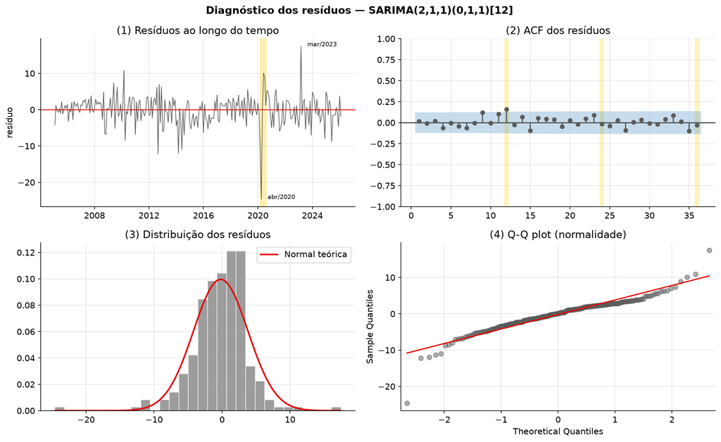

```python
fig, axes = plt.subplots(2, 2, figsize=(13, 8))

# (1) Resíduos no tempo — média zero e variância constante
axes[0, 0].plot(resid.index, resid.values, color=INSPER_GRAY, lw=0.8)
axes[0, 0].axhline(0, color=INSPER_RED, lw=1)
axes[0, 0].axvspan(*COVID, color=INSPER_AMARELO, alpha=0.3)
for data in resid.abs().nlargest(2).index:                 # anota os dois maiores choques
    axes[0, 0].annotate(mes_ano(data), (data, resid[data]), fontsize=8,
                        xytext=(8, 0), textcoords='offset points')
axes[0, 0].set_title('(1) Resíduos ao longo do tempo'); axes[0, 0].set_ylabel('resíduo')

# (2) ACF dos resíduos — ausência de autocorrelação
plot_acf(resid, lags=36, zero=False, ax=axes[0, 1], color=INSPER_GRAY,
         vlines_kwargs={'colors': INSPER_GRAY})
marcar_sazonais(axes[0, 1])
axes[0, 1].set_title('(2) ACF dos resíduos')

# (3) Histograma + densidade normal — normalidade
axes[1, 0].hist(resid, bins=30, density=True, color=INSPER_GRAY, alpha=0.6, edgecolor='white')
xg = np.linspace(resid.min(), resid.max(), 200)
axes[1, 0].plot(xg, stats.norm.pdf(xg, resid.mean(), resid.std()), color=INSPER_RED, lw=2,
                label='Normal teórica')
axes[1, 0].set_title('(3) Distribuição dos resíduos'); axes[1, 0].legend()

# (4) Q-Q plot — normalidade nas caudas
qqplot(resid, line='s', ax=axes[1, 1], markerfacecolor=INSPER_GRAY,
       markeredgecolor=INSPER_GRAY, alpha=0.5)
axes[1, 1].get_lines()[1].set_color(INSPER_RED)
axes[1, 1].set_title('(4) Q-Q plot (normalidade)')

plt.suptitle(f'Diagnóstico dos resíduos — {nome_modelo}', fontweight='bold')
plt.tight_layout(); plt.show()
```

**Código**

```python
# Onde estão os maiores resíduos? E quais lags da ACF residual saem da banda?
display(insample.assign(abs_resid=insample['resid'].abs())
        .nlargest(5, 'abs_resid')[['ds', 'y', 'AutoARIMA', 'resid']].round(2)
        .rename(columns={'AutoARIMA': 'ajustado (1 passo)'}))

ac_res = acf(resid, nlags=36)
banda = 1.96 / np.sqrt(len(resid))
print("Lags da ACF residual fora da banda ±%.3f:" % banda,
      {l: round(ac_res[l], 3) for l in range(1, 37) if abs(ac_res[l]) > banda})
jb = stats.jarque_bera(resid)
print(f"Jarque-Bera (H0: normalidade): estatística = {jb.statistic:.1f}, p-valor = {jb.pvalue:.2e}")
print(f"Curtose em excesso = {stats.kurtosis(resid):.2f}  (Normal = 0)")
```

|  | ds | y | ajustado (1 passo) | resid |
| --- | --- | --- | --- | --- |
| 195 | 2020-04-01 | 68.66 | 93.25 | -24.59 |
| 230 | 2023-03-01 | 111.17 | 93.71 | 17.45 |
| 104 | 2012-09-01 | 100.22 | 112.46 | -12.23 |
| 122 | 2014-03-01 | 100.61 | 112.58 | -11.97 |
| 194 | 2020-03-01 | 92.72 | 104.06 | -11.34 |

```
Lags da ACF residual fora da banda ±0.123: {12: np.float64(0.157)}
Jarque-Bera (H0: normalidade): estatística = 475.2, p-valor = 6.49e-104
Curtose em excesso = 6.50  (Normal = 0)
```

### 8.3 Passo 3: teste formal de Ljung-Box

$H_0$: os resíduos são ruído branco. Como estimamos $m = p+q+P+Q = 4$ parâmetros ARMA, informamos `model_df=m`, e a estatística passa a seguir uma $\chi^2_{h-m}$. Testamos nos lags sazonais $h = 12, 24, 36$.

**Código**

```python
lb = acorr_ljungbox(resid, lags=[12, 24, 36], model_df=m)
lb.index.name = 'lag (h)'
display(lb.round(4))

alpha = 0.05
for h, pval in lb['lb_pvalue'].items():
    veredito = 'não rejeita H0 (compatível com ruído branco)' if pval > alpha else 'REJEITA H0 (autocorrelação remanescente)'
    print(f"h = {h:>2}: p = {pval:.3f} → {veredito}")
```

| lag (h) | lb_stat | lb_pvalue |
| --- | --- | --- |
| 12 | 15.9912 | 0.0425 |
| 24 | 25.3917 | 0.1869 |
| 36 | 34.8444 | 0.3342 |

```
h = 12: p = 0.043 → REJEITA H0 (autocorrelação remanescente)
h = 24: p = 0.187 → não rejeita H0 (compatível com ruído branco)
h = 36: p = 0.334 → não rejeita H0 (compatível com ruído branco)
```

**Leitura.** A ordem de prioridade é: (1) autocorrelação, (2) variância constante e (3) normalidade.

1. **Autocorrelação.**
   - Na ACF residual, **um único lag sai da banda: o lag 12** (≈ 0,16).
   - O Ljung-Box **rejeita no horizonte $h = 12$** (p ≈ 0,04) e **não rejeita em $h = 24$ e $h = 36$** (p ≈ 0,19 e 0,33).
   - Ou seja, os resíduos são *quase* ruído branco, com **um resto de correlação sazonal no lag 12**.
   - É coerente com a descritiva: o padrão de dezembro vem encolhendo, e um único SMA(1) com $\Theta \approx -0{,}86$ (média sazonal longa) não acompanha totalmente essa mudança.
2. **Variância e média.**
   - Média ≈ −0,20 contra desvio ≈ 4,0: não há viés sistemático.
   - A variância é razoavelmente estável, com dois choques claros: **abr/2020** (Covid, resíduo ≈ −25) e **mar/2023** (≈ +17).
3. **Normalidade.**
   - O Jarque-Bera rejeita com folga, e o Q-Q plot mostra **caudas pesadas** causadas por esses poucos meses extremos.
   - As previsões pontuais continuam válidas, mas os **intervalos de previsão tendem a ser otimistas** (mais estreitos do que deveriam).

**Veredito:** o modelo captura a tendência, a sazonalidade e a dinâmica de curto prazo, com uma ressalva no lag 12 (Ljung-Box marginal). Pela regra do Box-Jenkins, o próximo ciclo voltaria à identificação e testaria um termo sazonal extra (SAR(1) + SMA(1)) ou intervenções para Covid e efeitos de calendário. Isso fica fora do escopo pedido. Para a previsão a seguir, o resultado é aceitável, desde que se leve em conta essa ressalva.

## 9 Previsão: 24 meses à frente

Esta é a **Etapa 4 do Box-Jenkins**. A previsão já foi gerada na Seção 8 (`sf.forecast(..., h=24, level=[80, 95])`), com o mesmo modelo SARIMA$(2,1,1)(0,1,1)_{12}$.

**Código**

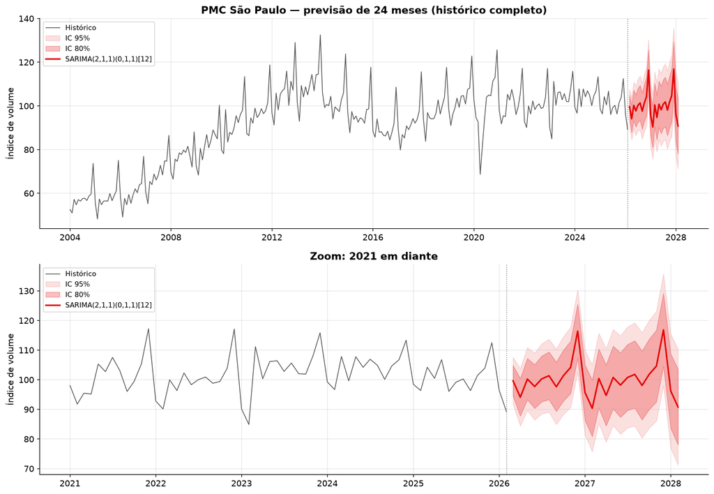

```python
def plot_previsao(ax, inicio=None, titulo=''):
    hist = df_sf if inicio is None else df_sf[df_sf['ds'] >= inicio]
    ax.plot(hist['ds'], hist['y'], color=INSPER_GRAY, lw=1, label='Histórico')
    ax.fill_between(previsao['ds'], previsao['AutoARIMA-lo-95'], previsao['AutoARIMA-hi-95'],
                    color=INSPER_RED, alpha=0.12, label='IC 95%')
    ax.fill_between(previsao['ds'], previsao['AutoARIMA-lo-80'], previsao['AutoARIMA-hi-80'],
                    color=INSPER_RED, alpha=0.25, label='IC 80%')
    ax.plot(previsao['ds'], previsao['AutoARIMA'], color=INSPER_RED, lw=2, label=nome_modelo)
    ax.axvline(df_sf['ds'].max(), color='gray', ls=':', lw=1)
    ax.set_title(titulo, fontweight='bold'); ax.set_ylabel('Índice de volume')
    ax.legend(loc='upper left', fontsize=9)


fig, axes = plt.subplots(2, 1, figsize=(13, 9))
plot_previsao(axes[0], titulo=f'PMC {MINHA_UF} — previsão de 24 meses (histórico completo)')
plot_previsao(axes[1], inicio='2021-01-01', titulo='Zoom: 2021 em diante')
plt.tight_layout(); plt.show()
```

**Código**

```python
# Tabela da previsão + largura dos intervalos por horizonte
tab_prev = previsao.drop(columns='unique_id').copy()
tab_prev.insert(0, 'h', range(1, H + 1))
tab_prev['largura IC80'] = tab_prev['AutoARIMA-hi-80'] - tab_prev['AutoARIMA-lo-80']
tab_prev['largura IC95'] = tab_prev['AutoARIMA-hi-95'] - tab_prev['AutoARIMA-lo-95']
tab_prev['ds'] = tab_prev['ds'].map(mes_ano)
tab_prev = tab_prev.rename(columns={'ds': 'mês', 'AutoARIMA': 'previsão',
                                    'AutoARIMA-lo-95': 'lo 95', 'AutoARIMA-lo-80': 'lo 80',
                                    'AutoARIMA-hi-80': 'hi 80', 'AutoARIMA-hi-95': 'hi 95'})
tab_prev[['h', 'mês', 'lo 95', 'lo 80', 'previsão', 'hi 80', 'hi 95',
          'largura IC80', 'largura IC95']].round(1).set_index('h')
```

| h | mês | lo 95 | lo 80 | previsão | hi 80 | hi 95 | largura IC80 | largura IC95 |
| --- | --- | --- | --- | --- | --- | --- | --- | --- |
| 1 | mar/2026 | 91.7 | 94.5 | 99.6 | 104.8 | 107.6 | 10.3 | 15.8 |
| 2 | abr/2026 | 84.4 | 87.8 | 94.1 | 100.4 | 103.8 | 12.7 | 19.4 |
| 3 | mai/2026 | 89.6 | 93.3 | 100.2 | 107.2 | 110.9 | 13.9 | 21.3 |
| 4 | jun/2026 | 86.4 | 90.3 | 97.7 | 105.1 | 109.0 | 14.8 | 22.6 |
| 5 | jul/2026 | 88.5 | 92.6 | 100.3 | 108.0 | 112.1 | 15.5 | 23.6 |
| 6 | ago/2026 | 89.1 | 93.3 | 101.4 | 109.4 | 113.6 | 16.1 | 24.6 |
| 7 | set/2026 | 84.9 | 89.3 | 97.6 | 105.9 | 110.3 | 16.6 | 25.4 |
| 8 | out/2026 | 88.2 | 92.8 | 101.3 | 109.9 | 114.5 | 17.2 | 26.2 |
| 9 | nov/2026 | 90.7 | 95.3 | 104.2 | 113.0 | 117.7 | 17.7 | 27.0 |
| 10 | dez/2026 | 102.5 | 107.3 | 116.4 | 125.5 | 130.3 | 18.2 | 27.8 |
| 11 | jan/2027 | 81.5 | 86.4 | 95.7 | 105.0 | 110.0 | 18.6 | 28.5 |
| 12 | fev/2027 | 75.8 | 80.8 | 90.3 | 99.9 | 104.9 | 19.1 | 29.2 |
| 13 | mar/2027 | 85.2 | 90.5 | 100.4 | 110.4 | 115.6 | 19.9 | 30.4 |
| 14 | abr/2027 | 79.0 | 84.4 | 94.7 | 105.0 | 110.4 | 20.6 | 31.5 |
| 15 | mai/2027 | 84.6 | 90.2 | 100.8 | 111.3 | 116.9 | 21.2 | 32.4 |
| 16 | jun/2027 | 81.6 | 87.3 | 98.2 | 109.1 | 114.8 | 21.7 | 33.2 |
| 17 | jul/2027 | 83.7 | 89.6 | 100.8 | 111.9 | 117.8 | 22.2 | 34.0 |
| 18 | ago/2027 | 84.4 | 90.4 | 101.8 | 113.2 | 119.2 | 22.8 | 34.8 |
| 19 | set/2027 | 80.3 | 86.4 | 98.1 | 109.7 | 115.9 | 23.3 | 35.6 |
| 20 | out/2027 | 83.6 | 89.9 | 101.8 | 113.7 | 119.9 | 23.7 | 36.3 |
| 21 | nov/2027 | 86.1 | 92.5 | 104.6 | 116.7 | 123.1 | 24.2 | 37.0 |
| 22 | dez/2027 | 98.0 | 104.5 | 116.8 | 129.2 | 135.7 | 24.7 | 37.7 |
| 23 | jan/2028 | 77.0 | 83.6 | 96.2 | 108.7 | 115.4 | 25.1 | 38.4 |
| 24 | fev/2028 | 71.2 | 78.0 | 90.8 | 103.6 | 110.3 | 25.6 | 39.1 |

**Código**

```python
# Âncora no histórico: previsão vs. o mesmo mês do último ano observado
ultimo_ano = y['2025-03-01':'2026-02-01'].to_numpy()
comparacao = pd.DataFrame({
    'mês': [MESES[m - 1] for m in previsao['ds'].dt.month.iloc[:12]],
    'observado (mar/25–fev/26)': ultimo_ano,
    'previsto 1º ano': previsao['AutoARIMA'].iloc[:12].values,
    'previsto 2º ano': previsao['AutoARIMA'].iloc[12:].values,
})
comparacao['previsto 1º − observado'] = comparacao['previsto 1º ano'] - comparacao['observado (mar/25–fev/26)']
comparacao.round(1)
```

|  | mês | observado (mar/25–fev/26) | previsto 1º ano | previsto 2º ano | previsto 1º − observado |
| --- | --- | --- | --- | --- | --- |
| 0 | mar | 104.2 | 99.6 | 100.4 | -4.6 |
| 1 | abr | 100.5 | 94.1 | 94.7 | -6.4 |
| 2 | mai | 106.8 | 100.2 | 100.8 | -6.5 |
| 3 | jun | 96.1 | 97.7 | 98.2 | 1.6 |
| 4 | jul | 99.2 | 100.3 | 100.8 | 1.1 |
| 5 | ago | 100.3 | 101.4 | 101.8 | 1.1 |
| 6 | set | 96.3 | 97.6 | 98.1 | 1.3 |
| 7 | out | 101.5 | 101.3 | 101.8 | -0.1 |
| 8 | nov | 103.9 | 104.2 | 104.6 | 0.3 |
| 9 | dez | 112.5 | 116.4 | 116.8 | 3.9 |
| 10 | jan | 96.4 | 95.7 | 96.2 | -0.7 |
| 11 | fev | 89.2 | 90.3 | 90.8 | 1.1 |

## 10 Discussão

**1. O ACF/PACF da série original sugeriu sazonalidade? E tendência? Bate com o que você viu no gráfico de linha?**

Sim aos dois. A ACF do nível decai muito lentamente ($\rho_1 \approx 0{,}85$, todos os 36 lags significativos), o que é tendência e raiz unitária. Sobre esse decaimento há picos em 12, 24 e 36 (0,83, 0,63, 0,41), a assinatura de sazonalidade estocástica anual. Na PACF, o par de picos nos lags 12 e 13 reforça a dependência do mesmo mês do ano anterior. Isso bate com o gráfico de linha: crescimento até 2013, queda em 2014–16, patamar ≈ 100 desde 2021 e o pico de dezembro todo ano. A STL confirmou os dois componentes como fortes ($F_T \approx 0{,}95$, $F_S \approx 0{,}77$) e mostrou que a amplitude sazonal muda ao longo do tempo.

**2. Quantas diferenças (regular e sazonal) o AutoARIMA aplicou? E os componentes AR/MA? Conseguiu observar isso no ACF/PACF?**

O modelo escolhido foi SARIMA$(2,1,1)(0,1,1)_{12}$: **uma diferença regular e uma sazonal**. É exatamente o que vimos nos dados: em $\Delta_{12}Y$ a ACF ainda decaía devagar e o KPSS rejeitava, e só $\Delta\Delta_{12}Y$ passou nos dois testes, com `nsdiffs` = 1 e `ndiffs` = 1. O **SMA(1)** ($\Theta \approx -0{,}86$) aparece claramente na ACF de $\Delta\Delta_{12}Y$, com pico negativo isolado no lag 12 e a PACF decaindo em 12 e 24. Na parte não-sazonal, os lags 1–2 negativos sugeriam um MA ou AR de baixa ordem. O AutoARIMA combinou AR(1) ($\phi_1 \approx 0{,}51$) e MA(1) ($\theta_1 \approx -0{,}80$) e manteve um $\phi_2 \approx 0$ não significativo. A identificação manual (*airline*) acertou as diferenças e o termo sazonal; o AutoARIMA refinou a dinâmica de curto prazo.

**3. Os resíduos parecem white noise? Algum padrão remanescente sazonal?**

Quase. A média é ≈ 0, a variância é razoavelmente estável (fora o Covid em abr/2020 e mar/2023), e o Ljung-Box não rejeita em $h = 24$ e $36$. **Mas sobra correlação no lag 12** (≈ 0,16, o único lag fora da banda), e o Ljung-Box em $h = 12$ rejeita a 5% (p ≈ 0,04). É um resto sazonal, coerente com a perda de peso de dezembro ao longo dos anos (de 1,28× para 1,11× a média anual). Os resíduos também não são normais (caudas pesadas por causa dos choques), o que torna os intervalos otimistas.

**4. A previsão pareceu razoável visualmente (captura a sazonalidade, fica bem ancorada no histórico, intervalos abrem muito com o horizonte)?**

Sim, com ressalvas. A previsão reproduz bem o perfil sazonal (pico em dezembro, vale em fevereiro) e fica ancorada no patamar ≈ 100 dos últimos anos, sem inventar tendência. Os primeiros meses (mar–mai/2026) saem 5–6 pontos abaixo de 2025, porque o modelo propaga o início fraco de 2026. O dezembro projetado (≈ 116) parece alto diante de dez/2025 (112,5), reflexo do mesmo resto sazonal do item 3. Os intervalos abrem bastante, como é natural num modelo com $d = 1$ e $D = 1$: o IC 95% passa de ≈ 16 pontos em $h = 1$ para ≈ 39 em $h = 24$. Mesmo assim, provavelmente subestimam o risco de choques.

**5. Que outras UFs você imagina que dariam um SARIMA bem diferente do seu (e por quê)?**

São Paulo é uma série longa, de economia grande e diversificada, com sazonalidade de varejo clássica (Natal) e tendência guiada pelo ciclo nacional. Hipóteses de UFs que dariam modelos diferentes:

- **Estados pequenos do Norte (Amapá, Roraima, Acre):** séries com muito mais ruído e crescimento estrutural forte. Devem pedir transformação log (variância crescente com o nível) e talvez ter sazonalidade relativamente mais fraca, ou $D = 0$.
- **Estados do agronegócio (Mato Grosso, Goiás, Mato Grosso do Sul):** como o varejo **ampliado** inclui veículos e materiais de construção, o calendário da safra pode deslocar o pico para o 1º semestre e criar tendência de crescimento mais acentuada.
- **Rio Grande do Sul:** a enchente de maio/2024 é um outlier tão forte quanto o Covid e exigiria intervenção.
- **Distrito Federal:** a renda ancorada no setor público deve produzir uma série menos cíclica, com tendência mais suave e menos sensível às recessões.